# COVID-19 Data Analysis

2023-10-01

## Download Links

You can download the reproducible .RMD document from which this knitted HTML was generated from the links below.

- DTSA5301_COVID19.Rmd ([Raw](https://raw.githubusercontent.com/estersstirrer/DTSA5301/main/DTSA5301_COVID19.Rmd))
- DTSA5301_COVID19.html ([Raw](https://raw.githubusercontent.com/estersstirrer/DTSA5301/main/DTSA5301_COVID19.html))

If your browser does not handle the above links well, please visit [my github.com repository](https://github.com/estersstirrer/DTSA5301/) to find and grab [the RMD file](https://github.com/estersstirrer/DTSA5301/blob/main/DTSA5301_COVID19.Rmd) from there.

## Abstract

In this report, I demonstrated how to import and process the daily US COVID-19 cases and deaths data available from the Johns Hopkins University GitHub Repository for visualization and analysis, maintaining reproducibility.

## Library Dependencies

For this project, I need only basic libraries, `'tidyverse'` and `'lubridate'`.

```r
library(tidyverse)
library(lubridate)
```

## Data Preparation

### Importing COVID-19 Data

Johns Hopkins University provides daily time series summary tables incorporated from daily case reports, including confirmed, deceased, and recovered cases. The University compiled the two-time series tables for US-confirmed cases and deaths reported at the county level.

In this analysis, I will focus on the following data from the United States reports, importing directly from [Johns Hopkins University’s Official GitHub Repository](https://catalog.data.gov/dataset) to make this report reproducible.

- time_series_covid19_confirmed_US.csv
- time_series_covid19_deaths_US.csv

```r
us_by_state_confirmed_csv <- read.csv("https://raw.githubusercontent.com/CSSEGISandData/COVID-19/master/csse_covid_19_data/csse_covid_19_time_series/time_series_covid19_confirmed_US.csv")
us_by_state_deaths_csv <- read.csv("https://raw.githubusercontent.com/CSSEGISandData/COVID-19/master/csse_covid_19_data/csse_covid_19_time_series/time_series_covid19_deaths_US.csv")
```

I keep this COVID-19 Data in `tibble` objects for efficient manipulation.

```r
us_by_state_confirmed_all <- tibble(us_by_state_confirmed_csv)
us_by_state_confirmed_all
```

```
## # A tibble: 3,342 × 1,154
##         UID iso2  iso3  code3  FIPS Admin2   Province_State Country_Region   Lat
##       <int> <chr> <chr> <int> <dbl> <chr>    <chr>          <chr>          <dbl>
##  1 84001001 US    USA     840  1001 Autauga  Alabama        US              32.5
##  2 84001003 US    USA     840  1003 Baldwin  Alabama        US              30.7
##  3 84001005 US    USA     840  1005 Barbour  Alabama        US              31.9
##  4 84001007 US    USA     840  1007 Bibb     Alabama        US              33.0
##  5 84001009 US    USA     840  1009 Blount   Alabama        US              34.0
##  6 84001011 US    USA     840  1011 Bullock  Alabama        US              32.1
##  7 84001013 US    USA     840  1013 Butler   Alabama        US              31.8
##  8 84001015 US    USA     840  1015 Calhoun  Alabama        US              33.8
##  9 84001017 US    USA     840  1017 Chambers Alabama        US              32.9
## 10 84001019 US    USA     840  1019 Cherokee Alabama        US              34.2
## # ℹ 3,332 more rows
## # ℹ 1,145 more variables: Long_ <dbl>, Combined_Key <chr>, X1.22.20 <int>,
## #   X1.23.20 <int>, X1.24.20 <int>, X1.25.20 <int>, X1.26.20 <int>,
## #   X1.27.20 <int>, X1.28.20 <int>, X1.29.20 <int>, X1.30.20 <int>,
## #   X1.31.20 <int>, X2.1.20 <int>, X2.2.20 <int>, X2.3.20 <int>, X2.4.20 <int>,
## #   X2.5.20 <int>, X2.6.20 <int>, X2.7.20 <int>, X2.8.20 <int>, X2.9.20 <int>,
## #   X2.10.20 <int>, X2.11.20 <int>, X2.12.20 <int>, X2.13.20 <int>, …
```

```r
us_by_state_deaths_all <- tibble(us_by_state_deaths_csv)
us_by_state_deaths_all
```

```
## # A tibble: 3,342 × 1,155
##         UID iso2  iso3  code3  FIPS Admin2   Province_State Country_Region   Lat
##       <int> <chr> <chr> <int> <dbl> <chr>    <chr>          <chr>          <dbl>
##  1 84001001 US    USA     840  1001 Autauga  Alabama        US              32.5
##  2 84001003 US    USA     840  1003 Baldwin  Alabama        US              30.7
##  3 84001005 US    USA     840  1005 Barbour  Alabama        US              31.9
##  4 84001007 US    USA     840  1007 Bibb     Alabama        US              33.0
##  5 84001009 US    USA     840  1009 Blount   Alabama        US              34.0
##  6 84001011 US    USA     840  1011 Bullock  Alabama        US              32.1
##  7 84001013 US    USA     840  1013 Butler   Alabama        US              31.8
##  8 84001015 US    USA     840  1015 Calhoun  Alabama        US              33.8
##  9 84001017 US    USA     840  1017 Chambers Alabama        US              32.9
## 10 84001019 US    USA     840  1019 Cherokee Alabama        US              34.2
## # ℹ 3,332 more rows
## # ℹ 1,146 more variables: Long_ <dbl>, Combined_Key <chr>, Population <int>,
## #   X1.22.20 <int>, X1.23.20 <int>, X1.24.20 <int>, X1.25.20 <int>,
## #   X1.26.20 <int>, X1.27.20 <int>, X1.28.20 <int>, X1.29.20 <int>,
## #   X1.30.20 <int>, X1.31.20 <int>, X2.1.20 <int>, X2.2.20 <int>,
## #   X2.3.20 <int>, X2.4.20 <int>, X2.5.20 <int>, X2.6.20 <int>, X2.7.20 <int>,
## #   X2.8.20 <int>, X2.9.20 <int>, X2.10.20 <int>, X2.11.20 <int>, …
```

### Tidying and Transforming

To demonstrate how we can complete all steps in the data science process, I will tidy up and transform this COVID-19 Data step-by-step. Let’s see how it goes.

#### Narrowing Down

First, since I will not utilize the information in the following columns in this paper, I will remove them from both data frames to prevent extra memory consumption.

- `UID`
- `iso2`
- `iso3`
- `code3`
- `FIPS`
- `Admin2`
- `Lat`
- `Long_`
- `Combined_Key`

```r
us_by_state_confirmed_selected <- us_by_state_confirmed_all %>%
  select(-UID,
         -iso2,
         -iso3,
         -code3,
         -FIPS,
         -Admin2,
         -Lat,
         -Long_,
         -Combined_Key)
us_by_state_deaths_selected <- us_by_state_deaths_all %>%
  select(-UID,
         -iso2,
         -iso3,
         -code3,
         -FIPS,
         -Admin2,
         -Lat,
         -Long_,
         -Combined_Key)
```

#### Renaming

Second, although it’s my preference, I redefine the column names shorter using camel case notation to make it easier to type and handle.

```r
us_by_state_confirmed_renamed <- us_by_state_confirmed_selected %>%
  rename(State = Province_State,
         Country = Country_Region)
us_by_state_deaths_renamed <- us_by_state_deaths_selected %>%
  rename(State = Province_State,
         Country = Country_Region)
```

Here is what we have got so far.

```r
us_by_state_confirmed_renamed
```

```
## # A tibble: 3,342 × 1,145
##    State  Country X1.22.20 X1.23.20 X1.24.20 X1.25.20 X1.26.20 X1.27.20 X1.28.20
##    <chr>  <chr>      <int>    <int>    <int>    <int>    <int>    <int>    <int>
##  1 Alaba… US             0        0        0        0        0        0        0
##  2 Alaba… US             0        0        0        0        0        0        0
##  3 Alaba… US             0        0        0        0        0        0        0
##  4 Alaba… US             0        0        0        0        0        0        0
##  5 Alaba… US             0        0        0        0        0        0        0
##  6 Alaba… US             0        0        0        0        0        0        0
##  7 Alaba… US             0        0        0        0        0        0        0
##  8 Alaba… US             0        0        0        0        0        0        0
##  9 Alaba… US             0        0        0        0        0        0        0
## 10 Alaba… US             0        0        0        0        0        0        0
## # ℹ 3,332 more rows
## # ℹ 1,136 more variables: X1.29.20 <int>, X1.30.20 <int>, X1.31.20 <int>,
## #   X2.1.20 <int>, X2.2.20 <int>, X2.3.20 <int>, X2.4.20 <int>, X2.5.20 <int>,
## #   X2.6.20 <int>, X2.7.20 <int>, X2.8.20 <int>, X2.9.20 <int>, X2.10.20 <int>,
## #   X2.11.20 <int>, X2.12.20 <int>, X2.13.20 <int>, X2.14.20 <int>,
## #   X2.15.20 <int>, X2.16.20 <int>, X2.17.20 <int>, X2.18.20 <int>,
## #   X2.19.20 <int>, X2.20.20 <int>, X2.21.20 <int>, X2.22.20 <int>, …
```

```r
us_by_state_deaths_renamed
```

```
## # A tibble: 3,342 × 1,146
##    State   Country Population X1.22.20 X1.23.20 X1.24.20 X1.25.20 X1.26.20
##    <chr>   <chr>        <int>    <int>    <int>    <int>    <int>    <int>
##  1 Alabama US           55869        0        0        0        0        0
##  2 Alabama US          223234        0        0        0        0        0
##  3 Alabama US           24686        0        0        0        0        0
##  4 Alabama US           22394        0        0        0        0        0
##  5 Alabama US           57826        0        0        0        0        0
##  6 Alabama US           10101        0        0        0        0        0
##  7 Alabama US           19448        0        0        0        0        0
##  8 Alabama US          113605        0        0        0        0        0
##  9 Alabama US           33254        0        0        0        0        0
## 10 Alabama US           26196        0        0        0        0        0
## # ℹ 3,332 more rows
## # ℹ 1,138 more variables: X1.27.20 <int>, X1.28.20 <int>, X1.29.20 <int>,
## #   X1.30.20 <int>, X1.31.20 <int>, X2.1.20 <int>, X2.2.20 <int>,
## #   X2.3.20 <int>, X2.4.20 <int>, X2.5.20 <int>, X2.6.20 <int>, X2.7.20 <int>,
## #   X2.8.20 <int>, X2.9.20 <int>, X2.10.20 <int>, X2.11.20 <int>,
## #   X2.12.20 <int>, X2.13.20 <int>, X2.14.20 <int>, X2.15.20 <int>,
## #   X2.16.20 <int>, X2.17.20 <int>, X2.18.20 <int>, X2.19.20 <int>, …
```

#### Pivotting

Third, we must transform every date column into a separate dedicated row to allow us to visualize these data in time-series graphs later.

```r
us_by_state_confirmed_transformed <- us_by_state_confirmed_renamed %>%
  pivot_longer(cols = -c(State, Country),
               names_to = "Date",
               values_to = "Cases")
us_by_state_deaths_transformed <- us_by_state_deaths_renamed %>%
  pivot_longer(cols = -c(State, Country, Population),
               names_to = "Date",
               values_to = "Deaths")
```

#### Aggregating

Since we only have accumulated by-state numbers of COVID-19 cases and deaths in the data frames, we have to synthesize the numbers for newly reported, daily occurred cases and fatalities by calculations.

```r
us_by_state_confirmed_aggregated <- us_by_state_confirmed_transformed %>%
  mutate(Date = str_remove(Date, "X")) %>%
  mutate(Date = mdy(Date)) %>%
  group_by(State, Date) %>%
  summarize(Cases = sum(Cases)) %>%
  mutate(PrevCases = lag(Cases),
         NewCases = ifelse(is.na(PrevCases), Cases, Cases - PrevCases)) %>%
  select(-c(PrevCases)) %>%
  arrange(State, Date)
us_by_state_deaths_aggregated <- us_by_state_deaths_transformed %>%
  mutate(Date = str_remove(Date, "X")) %>%
  mutate(Date = mdy(Date)) %>%
  group_by(State, Date) %>%
  summarize(Deaths = sum(Deaths),
            Population = max(Population)) %>%
  mutate(PrevDeaths = lag(Deaths),
         NewDeaths = ifelse(is.na(PrevDeaths), Deaths, Deaths - PrevDeaths)) %>%
  select(-c(PrevDeaths)) %>%
  arrange(State, Date)
```

Again, here is what we have got so far.

```r
us_by_state_confirmed_aggregated
```

```
## # A tibble: 66,294 × 4
## # Groups:   State [58]
##    State   Date       Cases NewCases
##    <chr>   <date>     <int>    <int>
##  1 Alabama 2020-01-22     0        0
##  2 Alabama 2020-01-23     0        0
##  3 Alabama 2020-01-24     0        0
##  4 Alabama 2020-01-25     0        0
##  5 Alabama 2020-01-26     0        0
##  6 Alabama 2020-01-27     0        0
##  7 Alabama 2020-01-28     0        0
##  8 Alabama 2020-01-29     0        0
##  9 Alabama 2020-01-30     0        0
## 10 Alabama 2020-01-31     0        0
## # ℹ 66,284 more rows
```

```r
us_by_state_deaths_aggregated
```

```
## # A tibble: 66,294 × 5
## # Groups:   State [58]
##    State   Date       Deaths Population NewDeaths
##    <chr>   <date>      <int>      <int>     <int>
##  1 Alabama 2020-01-22      0     658573         0
##  2 Alabama 2020-01-23      0     658573         0
##  3 Alabama 2020-01-24      0     658573         0
##  4 Alabama 2020-01-25      0     658573         0
##  5 Alabama 2020-01-26      0     658573         0
##  6 Alabama 2020-01-27      0     658573         0
##  7 Alabama 2020-01-28      0     658573         0
##  8 Alabama 2020-01-29      0     658573         0
##  9 Alabama 2020-01-30      0     658573         0
## 10 Alabama 2020-01-31      0     658573         0
## # ℹ 66,284 more rows
```

#### Combining

So far, we have been tidying up our data stored in two separate data frames; one is for COVID-19 cases, and the other is for deaths.

Now, it’s time to combine them into one with the `cbind()` function. But, you may wonder, “Shouldn’t we use the `full_join()` function instead of `cbind()`?” And the answer is, “Yes, basically, we should.”

However, the `full_join()` function requires much more computational resources than `cbind()` and might lead to a knitting failure due to a memory shortage depending on the runtime environment. Here, we can safely use the `cbind()` function for our purpose. So I will go with it for now.

```r
df1 <- us_by_state_confirmed_aggregated %>%
  arrange(State, Date)
df2 <- us_by_state_deaths_aggregated %>%
  rename(State2 = State, Date2 = Date) %>%
  arrange(State2, Date2)
us_by_state_combined <- cbind(df1, df2)
```

#### Validating

We can check whether there are any inconsistencies by querying such rows that have inconsistent keys. As shown below, no such rows exist; we could compile them without ruining them.

```r
us_by_state_combined %>% filter(State != State2 | Date != Date2)
```

```
## # A tibble: 0 × 9
## # Groups:   State [0]
## # ℹ 9 variables: State <chr>, Date <date>, Cases <int>, NewCases <int>,
## #   State2 <chr>, Date2 <date>, Deaths <int>, Population <int>, NewDeaths <int>
```

#### Finishing

Finally, I will organize our data, filtering out useless rows and columns and sorting in time-ascending order.

```r
us_by_state <- us_by_state_combined %>%
  filter(Cases != 0 | NewCases != 0 | Deaths != 0 | NewDeaths != 0) %>%
  select(-c(State2, Date2)) %>%
  select(Date, State, Population, everything()) %>%
  arrange(Date, State)
us_by_state
```

```
## # A tibble: 63,264 × 7
## # Groups:   State [58]
##    Date       State      Population Cases NewCases Deaths NewDeaths
##    <date>     <chr>           <int> <int>    <int>  <int>     <int>
##  1 2020-01-22 Ohio          1316756     0        0      1         1
##  2 2020-01-22 Washington    2252782     1        1      0         0
##  3 2020-01-23 Ohio          1316756     0        0      1         0
##  4 2020-01-23 Washington    2252782     1        0      0         0
##  5 2020-01-24 Illinois      5150233     1        1      0         0
##  6 2020-01-24 Ohio          1316756     0        0      1         0
##  7 2020-01-24 Washington    2252782     1        0      0         0
##  8 2020-01-25 Illinois      5150233     1        0      0         0
##  9 2020-01-25 Ohio          1316756     0        0      1         0
## 10 2020-01-25 Washington    2252782     1        0      0         0
## # ℹ 63,254 more rows
```

## Analyzing Data with Visualization

### Visualizing of the Daily Number of New COVID-19 Cases and Deaths in the United States

First, let’s visualize the overall number of COVID-19 cases and deaths by plotting them over time by day and see what we get.

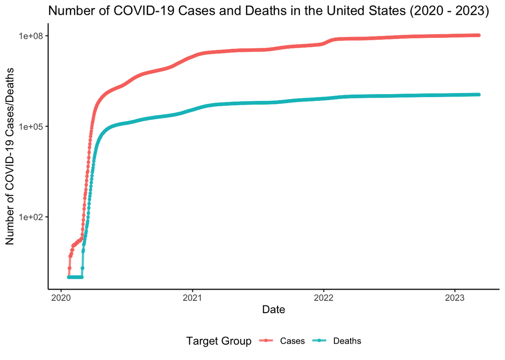

```r
us_by_state %>%
  group_by(Date) %>%
  summarize(Cases = sum(Cases),
            Deaths = sum(Deaths)) %>%
  pivot_longer(cols = -c(Date),
               names_to = "Kind",
               values_to = "Count") %>%
  ggplot(aes(x = Date, y = Count, color = Kind)) +
  geom_line(linewidth = 1, alpha = 0.8) +
  geom_point(size = 1, alpha = 0.8) +
  scale_y_log10() +
  labs(title = "Number of COVID-19 Cases and Deaths in the United States (2020 - 2023)",
       x = "Date",
       y = "Number of COVID-19 Cases/Deaths",
       color = "Target Group") +
  theme_classic() +
  theme(legend.position = "bottom")
```

Continuing, I am going to plot the daily number of new cases reported for COVID-19. As can be seen, there are significant spikes at roughly six-month cycles.

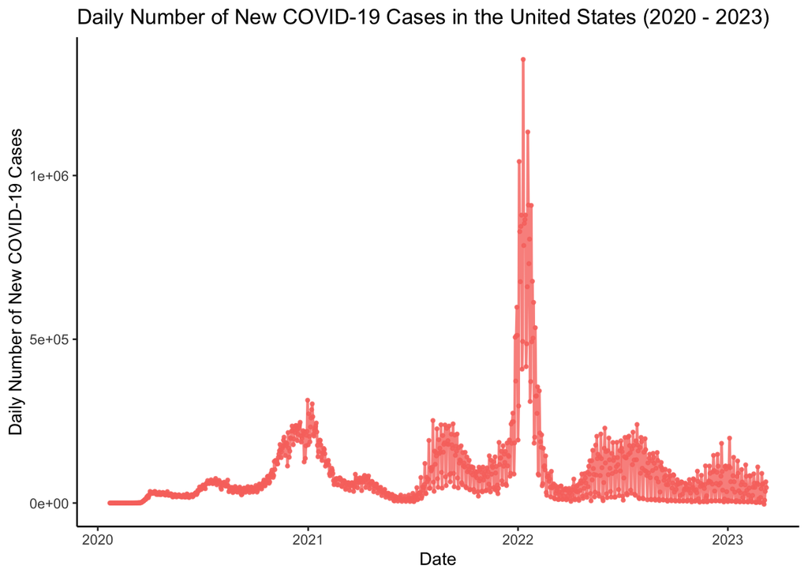

```r
us_by_state %>%
  group_by(Date) %>%
  summarize(NewCases = sum(NewCases)) %>%
  pivot_longer(cols = -c(Date),
               names_to = "Kind",
               values_to = "Count") %>%
  ggplot(aes(x = Date, y = Count, color = Kind)) +
  geom_line(linewidth = 0.8, alpha = 0.8) +
  geom_point(size = 0.8, alpha = 0.8) +
  labs(title = "Daily Number of New COVID-19 Cases in the United States (2020 - 2023)",
       x = "Date",
       y = "Daily Number of New COVID-19 Cases",
       color = "Target Group") +
  theme_classic() +
  theme(legend.position = "none")
```

Similarly, plotting the number of new deaths reported daily in COVID-19, we get a similar trend: roughly a semi-annual increase in deaths.

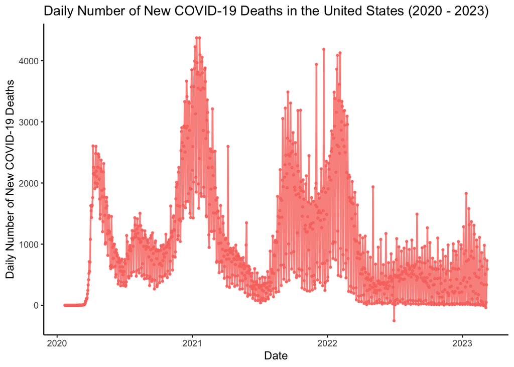

```r
us_by_state %>%
  group_by(Date) %>%
  summarize(NewDeaths = sum(NewDeaths)) %>%
  pivot_longer(cols = -c(Date),
               names_to = "Kind",
               values_to = "Count") %>%
  ggplot(aes(x = Date, y = Count, color = Kind)) +
  geom_line(linewidth = 0.8, alpha = 0.8) +
  geom_point(size = 0.8, alpha = 0.8) +
  labs(title = "Daily Number of New COVID-19 Deaths in the United States (2020 - 2023)",
       x = "Date",
       y = "Daily Number of New COVID-19 Deaths",
       color = "Target Group") +
  theme_classic() +
  theme(legend.position = "none")
```

### Visualizing the COVID-19 Fatality Rate in the United States by Month

Now, I will visualize how the fatality rate from COVID-19 infections in the US has changed over time from 2020 to 2023.

In conjunction with the visualization of the observed data, I will plot the predicted values from a linear regression model that represents the fatality rate of COVID-19 infections in all US states as a function of a series of dates. The independent variable will be the date over time, and the dependent variable will be the fatality rate.

By visualizing and modeling the fatality rate, I will be able to find whether we are acquiring immunity to COVID-19 and gaining effective resistance or not.

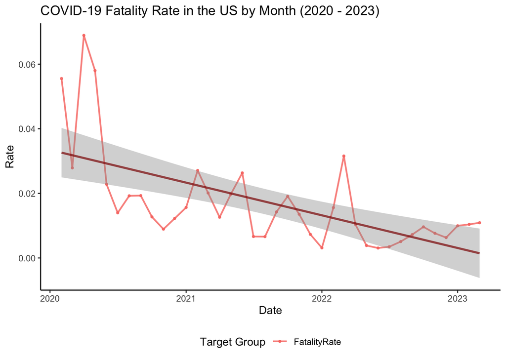

```r
df <- us_by_state %>%
  mutate(Date = floor_date(Date, "month")) %>%
  filter(Date >= ymd('2020-02-01')) %>%
  group_by(Date) %>%
  summarize(FatalityRate = sum(NewDeaths)/sum(NewCases))
df %>%
  pivot_longer(cols = -c(Date),
               names_to = "Kind",
               values_to = "Count") %>%
  ggplot(aes(x = Date, y = Count, color = Kind)) +
  geom_line(linewidth = 0.8, alpha = 0.8) +
  geom_point(size = 0.8, alpha = 0.8) +
  geom_smooth(data = df,
              aes(y = FatalityRate, x = Date),
              method = "lm",
              se = TRUE,
              color = alpha("darkred", 0.7)) +
  labs(title = "COVID-19 Fatality Rate in the US by Month (2020 - 2023)",
       x = "Date",
       y = "Rate",
       color = "Target Group") +
  theme_classic() +
  theme(legend.position = "bottom")
```

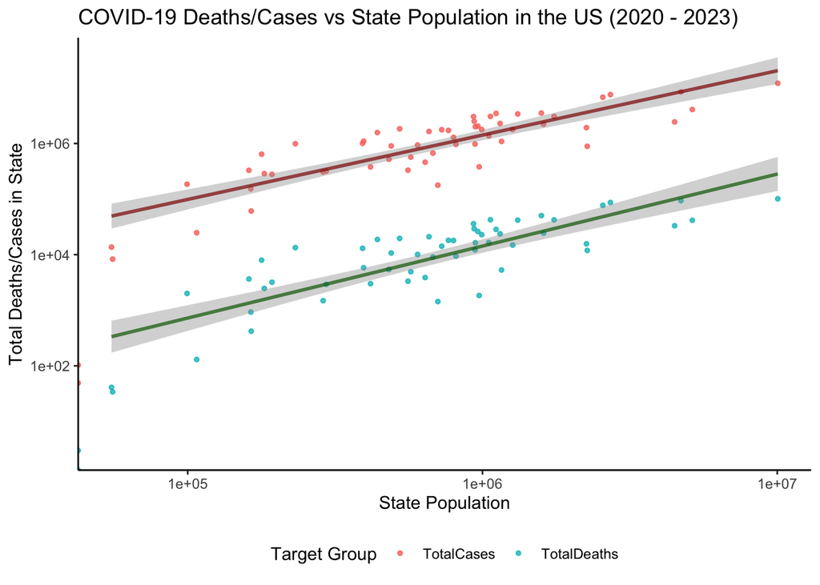

```r
df <- us_by_state %>%
  mutate(Date = floor_date(Date, "month")) %>%
  filter(Date >= ymd('2020-02-01')) %>%
  group_by(State) %>%
  summarize(TotalDeaths = max(Deaths),
            TotalCases = max(Cases),
            Population = max(Population))
df %>%
  pivot_longer(cols = -c(State, Population),
               names_to = "Indicator",
               values_to = "Value") %>%
  ggplot(aes(x = Population, y = Value, color = Indicator)) +
  geom_point(size = 1, alpha = 0.8) +
  scale_y_log10() +
  scale_x_log10() +
  geom_smooth(data = df,
              aes(y = TotalCases, x = Population),
              method = "lm",
              se = TRUE,
              color = alpha("darkred", 0.7)) +
  geom_smooth(data = df,
              aes(y = TotalDeaths, x = Population),
              method = "lm",
              se = TRUE,
              color = alpha("darkgreen", 0.7)) +
  labs(title = "COVID-19 Deaths/Cases vs State Population in the US (2020 - 2023)",
       x = "State Population",
       y = "Total Deaths/Cases in State",
       color = "Target Group") +
  theme_classic() +
  theme(legend.position = "bottom")
```

### Analysis and Thoughts

#### Daily Number of New COVID-19 Cases and Deaths in the United States

The first graph clearly shows that COVID-19 infections increased rapidly since the epidemic in early 2020. Although it is hard to see from the first graph, there was remarkable fluctuation over the period. We can see significant spikes at roughly six-month cycles in the second and third graphs. The cyclic wave of COVID-19 infections is quite intriguing, but I suspect the mechanism under the hood is far more complicated than it looks and maybe beyond this paper.

## Conclusion

In this report, I demonstrated how we can import, tidy, transform, visualize, and analyze open data available from the Johns Hopkins University GitHub Repository in a reproducible manner. The reproducibility sometimes fails due to unexpected runtime environment limitations like available memory footprint. I tried to make this Rmd document as reproducible as possible but found it more challenging than I thought.

Speaking of the findings from the data analysis, I have observed the following:

The observations strongly stimulate my interest. I want to acquire enough skills to approach and analyze those things deeply.

## Bias Identification

The source data itself can be subject to a variety of biases. In particular, two major ones are possible: selection bias and information bias. I want to mention the strong possibility of selection bias, which implies that the sampling is not truly random but biased.

According to a Wikipedia article, [COVID-19 testing in the United States](https://en.wikipedia.org/wiki/COVID-19_testing_in_the_United_States), only some suspicious patients/infected persons in the US were eligible for genetic testing for the COVID-19 virus until December 2020. However, determining who is “suspicious” is problematic because COVID-19 symptoms are similar to the common cold or influenza, and we also have a high rate of asymptomatic cases. Hence, the early data, especially early 2020, should be highly skewed.

Even after the FDA approved the test for anyone with and without COVID-19 symptoms using a $30 rapid testing kit available without a prescription in December 2020, there was still possible bias. I suspect that not all people could buy or would be willing to buy and test themselves for COVID-19 infection.